# Doing Analysis with Health Data

# We ask so many questions!

One of my (many) questions is in regards to drug overdoses:

# **Has the rate of drug overdose deaths changed over time?**

- Why might this be an important question?
- Why is it an economics question?
- How does it pertain to health economics, as we have studies so far?

## A big question requires big data

The CDC has a neat portal to access health data. While not the most detailed, it can give us a start!

Let’s visit it!

CDC Wonder

## Finding the data that is right for the job

What we need is **mortality** data.

- Drug related deaths
- Recent time period (until most recent available)
- Preferably aggregated to the county or state level (maybe even national)

[Link to Data](https://wonder.cdc.gov/ucd-icd10.html)

[The Underlying Cause of Death Datafile Description](https://wonder.cdc.gov/wonder/help/ucd.html#)

> The Underlying Cause of Death data available on WONDER are county-level national mortality and population data spanning the years 1999-2017. Data are based on death certificates for U.S. residents. Each death certificate identifies a single underlying cause of death and demographic data. The number of deaths, crude death rates or age-adjusted death rates, and 95% confidence intervals and standard errors for death rates can be obtained by place of residence (total U.S., region, state and county), age group (single-year-of age, 5-year age groups, 10-year age groups and infant age groups), race, Hispanic ethnicity, gender, year, cause-of-death (4-digit ICD-10 code or group of codes), injury intent and injury mechanism, drug/alcohol induced causes and urbanization categories. Data are also available for place of death, month and week day of death, and whether an autopsy was performed.

> The population estimates are U.S. Census Bureau estimates of U.S. national, state, and county resident populations. The year 1999 population estimates are bridged-race intercensal estimates of the July 1 resident population, based on the year 1990 and the year 2000 census counts. The year 2000 and year 2010 population estimates are April 1 modified census counts, with bridged-race categories. The 2001 - 2009 population estimates are bridged-race revised intercensal estimates of the July 1 resident population, based on the year 2000 and the year 2010 census counts (released by NCHS on 10/26/2012). The 2001 - 2009 archive population estimates are bridged-race postcensal estimates of the July 1 resident population. The 2011 - 2017 population estimates are bridged-race postcensal estimates of the July 1 resident population. For more information, see Population Data Sources.

## Let’s download this data, grouping by state, year, and drug/alcohol induced cause

#### Importing it into our spreadsheet (here using R):

```r
deaths <- read.delim(file="C:/Users/rselby/OneDrive - emporia.edu/GitHub/Health-Econ/data/ucod97.txt", header = TRUE, sep = "\t", dec = ".")
head(deaths)
```

|  | Notes | State | State.Code | Year | Year.Code | Drug.Alcohol.Induced.Cause | Drug.Alcohol.Induced.Cause.Code | Deaths | Population | Crude.Rate |
| --- | --- | --- | --- | --- | --- | --- | --- | --- | --- | --- |
| 1 |  | Alabama | 1 | 1999 | 1999 | Drug poisonings (overdose) Unintentional (X40-X44) | D1 | 116 | 4430141 | 2.62 |
| 2 |  | Alabama | 1 | 1999 | 1999 | Drug poisonings (overdose) Suicide (X60-X64) | D2 | 37 | 4430141 | 0.84 |
| 3 |  | Alabama | 1 | 1999 | 1999 | Drug poisonings (overdose) Undetermined (Y10-Y14) | D4 | 16 | 4430141 | Unreliable |
| 4 |  | Alabama | 1 | 1999 | 1999 | All other drug-induced causes | D9 | 26 | 4430141 | 0.59 |
| 5 |  | Alabama | 1 | 1999 | 1999 | All other alcohol-induced causes | A9 | 248 | 4430141 | 5.60 |
| 6 |  | Alabama | 1 | 1999 | 1999 | All other non-drug and non-alcohol causes | O9 | 44362 | 4430141 | 1001.37 |

#### And giving it a quick one-over on the important variables

```r
library(plyr)
count(deaths, vars="State")
```

| State | freq |
| --- | --- |
|  | 49 |
| Alabama | 125 |
| Alaska | 88 |
| Arizona | 128 |
| Arkansas | 123 |
| California | 136 |
| Colorado | 132 |
| Connecticut | 122 |
| Delaware | 88 |
| District of Columbia | 85 |

[output cut: 42 more lines]

```r
count(deaths, 'Year')
```

| Year | freq |
| --- | --- |
| 1999 | 275 |
| 2000 | 280 |
| 2001 | 286 |
| 2002 | 284 |
| 2003 | 296 |
| 2004 | 299 |
| 2005 | 297 |
| 2006 | 299 |
| 2007 | 318 |
| 2008 | 326 |

[output cut: 10 more lines]

```r
count(deaths, 'Drug.Alcohol.Induced.Cause')
```

| Drug.Alcohol.Induced.Cause | freq |
| --- | --- |
|  | 49 |
| Alcohol poisonings (overdose) (X45, X65, Y15) | 581 |
| All other alcohol-induced causes | 969 |
| All other drug-induced causes | 738 |
| All other non-drug and non-alcohol causes | 969 |
| Drug poisonings (overdose) Homicide (X85) | 21 |
| Drug poisonings (overdose) Suicide (X60-X64) | 904 |
| Drug poisonings (overdose) Undetermined (Y10-Y14) | 784 |
| Drug poisonings (overdose) Unintentional (X40-X44) | 956 |

#### Let’s see what happend with “Unintentional” drug poisonings over time

We need to create an “aggregate” national variable

```r
totaldeaths<-aggregate(Deaths ~ Year+Drug.Alcohol.Induced.Cause, data=deaths, FUN=sum)
totalpop<- aggregate(Population ~ Year+Drug.Alcohol.Induced.Cause, data=deaths, FUN=sum)
aggregate<-merge(totaldeaths,totalpop,by=c("Year","Drug.Alcohol.Induced.Cause"))
aggregate$rate<-100000*aggregate$Deaths/aggregate$Population
head(aggregate)
```

|  | Year | Drug.Alcohol.Induced.Cause | Deaths | Population | rate |
| --- | --- | --- | --- | --- | --- |
| 1 | 1999 | Alcohol poisonings (overdose) (X45, X65, Y15) | 250 | 124867549 | 0.2002121 |
| 2 | 1999 | All other alcohol-induced causes | 19108 | 279040168 | 6.8477596 |
| 3 | 1999 | All other drug-induced causes | 2186 | 253258787 | 0.8631487 |
| 4 | 1999 | All other non-drug and non-alcohol causes | 2352802 | 279040168 | 843.1768146 |
| 5 | 1999 | Drug poisonings (overdose) Suicide (X60-X64) | 3147 | 275203831 | 1.1435161 |
| 6 | 1999 | Drug poisonings (overdose) Undetermined (Y10-Y14) | 2407 | 257979823 | 0.9330187 |

```r
levels(aggregate$Drug.Alcohol.Induced.Cause)
```

```
[1] ""                                                   "Alcohol poisonings (overdose) (X45, X65, Y15)"
[3] "All other alcohol-induced causes"                   "All other drug-induced causes"
[5] "All other non-drug and non-alcohol causes"          "Drug poisonings (overdose) Homicide (X85)"
[7] "Drug poisonings (overdose) Suicide (X60-X64)"       "Drug poisonings (overdose) Undetermined (Y10-Y14)"
[9] "Drug poisonings (overdose) Unintentional (X40-X44)"
```

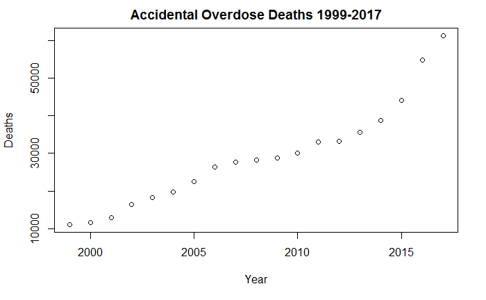

```r
totaldeathssub <- subset(aggregate,Drug.Alcohol.Induced.Cause=="Drug poisonings (overdose) Unintentional (X40-X44)")
plot(Deaths~Year, data=totaldeathssub, main="Accidental Overdose Deaths 1999-2017")
```

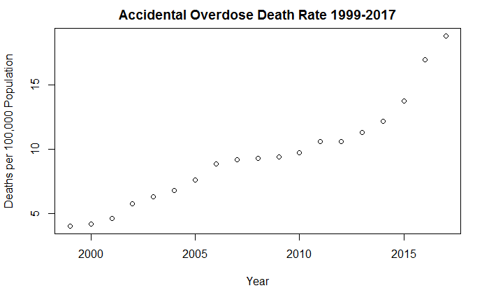

```r
plot(rate~Year, data=totaldeathssub, main="Accidental Overdose Death Rate 1999-2017", ylab = "Deaths per 100,000 Population")
```

## Regression Analysis

```r
library(stargazer)
reg <- lm(rate~Year,totaldeathssub)
stargazer(totaldeathssub)
```

```r
stargazer(reg, title="Regression Results", align=TRUE, type = 'html')
```

**Regression Results**

|  | *Dependent variable:* |
| --- | --- |
|  | rate |
| Year | 0.682*** |
|  | (0.052) |
| Constant | -1,359.495*** |
|  | (104.301) |
| Observations | 19 |
| R<sup>2</sup> | 0.910 |
| Adjusted R<sup>2</sup> | 0.905 |
| Residual Std. Error | 1.240 (df = 17) |
| F Statistic | 172.267*** (df = 1; 17) |
| *Note:* | p<0.1; p<0.05; p<0.01 |

## Adding in Controls

```r
library(readstata13)
deathssub <- subset(deaths,Drug.Alcohol.Induced.Cause=="Drug poisonings (overdose) Unintentional (X40-X44)")
urate <- read.dta13(file="state_urate.dta")
deathsurate<-merge(deathssub,urate,by.x=c("Year","State.Code"), by.y=c("year","FIPS_ST"))
head(deathsurate)
```

|  | Year | State.Code | Notes | State | Year.Code | Drug.Alcohol.Induced.Cause | Drug.Alcohol.Induced.Cause.Code | Deaths | Population | Crude.Rate | urate |
| --- | --- | --- | --- | --- | --- | --- | --- | --- | --- | --- | --- |
| 1 | 1999 | 1 |  | Alabama | 1999 | Drug poisonings (overdose) Unintentional (X40-X44) | D1 | 116 | 4430141 | 2.62 | 4.3 |
| 2 | 1999 | 10 |  | Delaware | 1999 | Drug poisonings (overdose) Unintentional (X40-X44) | D1 | 42 | 774990 | 5.42 | 3.3 |
| 3 | 1999 | 11 |  | District of Columbia | 1999 | Drug poisonings (overdose) Unintentional (X40-X44) | D1 | 47 | 570213 | 8.24 | 6.5 |
| 4 | 1999 | 12 |  | Florida | 1999 | Drug poisonings (overdose) Unintentional (X40-X44) | D1 | 681 | 15759421 | 4.32 | 4.0 |
| 5 | 1999 | 13 |  | Georgia | 1999 | Drug poisonings (overdose) Unintentional (X40-X44) | D1 | 219 | 8045965 | 2.72 | 3.8 |
| 6 | 1999 | 15 |  | Hawaii | 1999 | Drug poisonings (overdose) Unintentional (X40-X44) | D1 | 36 | 1210300 | 2.97 | 5.0 |

```r
deathsurate$rate<-100000*deathsurate$Deaths/deathsurate$Population
deathsurate$year.f<-factor(deathsurate$Year)
reg2<- lm(rate~Year,deathsurate)
reg3<- lm(rate~Year+urate,deathsurate)
reg4<- lm(rate~urate+year.f,deathsurate)
reg5<- lm(rate~urate+year.f+State,deathsurate)
stargazer(reg2,reg3,reg4,reg5, title="Regression Results", align=TRUE, type = 'html')
```

**Regression Results**

|  | *Dependent variable:* |  |  |  |
| --- | --- | --- | --- | --- |
|  | rate |  |  |  |
|  | (1) | (2) | (3) | (4) |
| Year | 0.576*** | 0.423*** |  |  |
|  | (0.031) | (0.037) |  |  |
| urate |  | 0.546*** | 0.991*** | 0.264*** |
|  |  | (0.075) | (0.092) | (0.094) |
| year.f2000 |  |  | 0.739 | 0.665 |
|  |  |  | (0.691) | (0.413) |
| year.f2001 |  |  | 0.673 | 0.944** |
|  |  |  | (0.692) | (0.414) |
| year.f2002 |  |  | 0.788 | 1.803*** |
|  |  |  | (0.700) | (0.430) |
| year.f2003 |  |  | 1.355* | 2.505*** |
|  |  |  | (0.700) | (0.434) |
| year.f2004 |  |  | 2.177*** | 3.149*** |
|  |  |  | (0.694) | (0.424) |
| year.f2005 |  |  | 2.969*** | 3.622*** |
|  |  |  | (0.691) | (0.417) |
| year.f2006 |  |  | 4.965*** | 5.255*** |
|  |  |  | (0.688) | (0.411) |
| year.f2007 |  |  | 5.209*** | 5.532*** |
|  |  |  | (0.684) | (0.409) |
| year.f2008 |  |  | 4.738*** | 5.760*** |
|  |  |  | (0.692) | (0.424) |
| year.f2009 |  |  | 1.469* | 4.786*** |
|  |  |  | (0.790) | (0.579) |
| year.f2010 |  |  | 1.653** | 5.194*** |
|  |  |  | (0.804) | (0.600) |
| year.f2011 |  |  | 3.416*** | 6.497*** |
|  |  |  | (0.775) | (0.558) |

[output cut: 112 more lines]